# Bayesian Methods for CDH dataset using Birth and 2yrs

Zanis Fang, UID: ZF2213

3/20/2019

### Data cleaning

**Cases selection** Death cases were removed because it would not reasonable to impute their follow-up data. After removal of death cases, “dead”, “discharge”, “SampleID”, “dc_dead_age”, “dc_alive_age” were also removed.

**Structural Imputation** NA’s in “gu_anomaly”, “clp”, “sk_anomalies”, “bps”, “ccam” can be imputed with 0 as long as “sys” is not NA. Since they added up to the number in “sys”.

Making categorical variables factors for downstream anaylsis. “sys”, “apgar_1”, “apgar_5” remains continuous since they are ordinal.

**Missing value imputation using EM algorithm**

Use expectation-maximization (EM) algorithm to impute missing values. Setting **8** underlying latent components.

**Scaling and centering the continuous variables**

**Does not need to normalization since the FAMD function would do it automatically**

Using square-root unit variance as scaling parameters. Centering around zero.

### Factor Analysis

FAMD (Factor Analysis for Mixed Data) is a principal component method dedicated to explore data with both continuous and categorical variables. It can be seen roughly as a mixed between PCA and MCA (multiple correspondence analysis).

Since the dataset contains a lot of categorical variables, it would be better to use factor analysis.

**Factor analysis results**

Eigenvalues:

|  | eigenvalue | percentage of variance | cumulative percentage of variance |
| --- | --- | --- | --- |
| comp 1 | 11.523283 | 18.890628 | 18.89063 |
| comp 2 | 5.508555 | 9.030418 | 27.92105 |
| comp 3 | 3.799206 | 6.228207 | 34.14925 |
| comp 4 | 3.436038 | 5.632848 | 39.78210 |
| comp 5 | 2.845915 | 4.665434 | 44.44753 |

Variables contribute most to the three dimensions are plotted and listed.

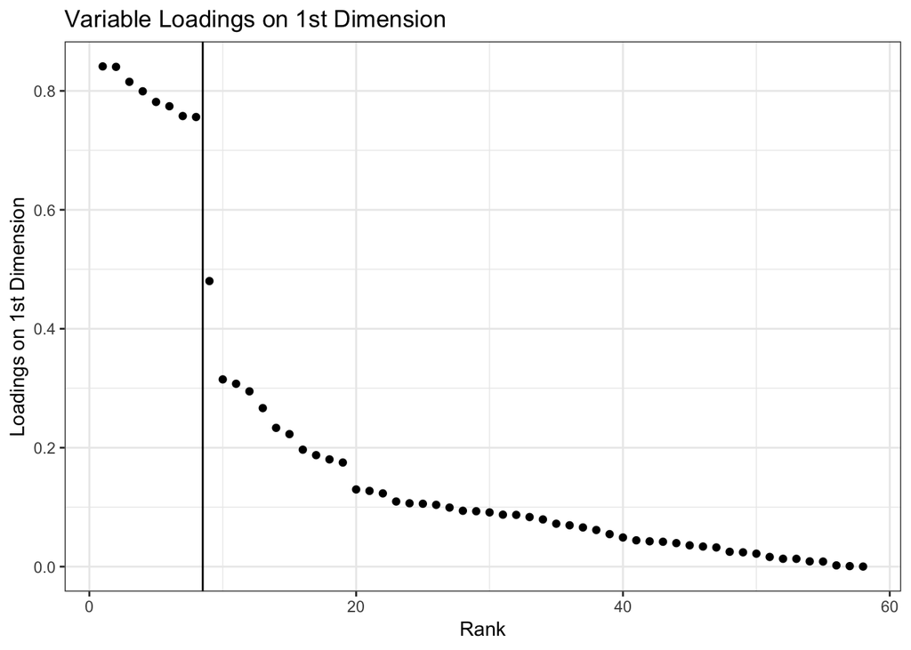

| variable | Dim.1 |
| --- | --- |
| da_lang_composite_score | 0.7992981 |
| da_cog_composite_score | 0.8403730 |
| da_mot_composite_score | 0.8152295 |
| vabs_com_stand_score | 0.7814223 |
| vabs_dai_liv_stand_score | 0.7560538 |
| vabs_soc_stand_score | 0.7576864 |
| vabs_mot_stand_score | 0.7741164 |
| vabs_adabehcomstand | 0.8411315 |

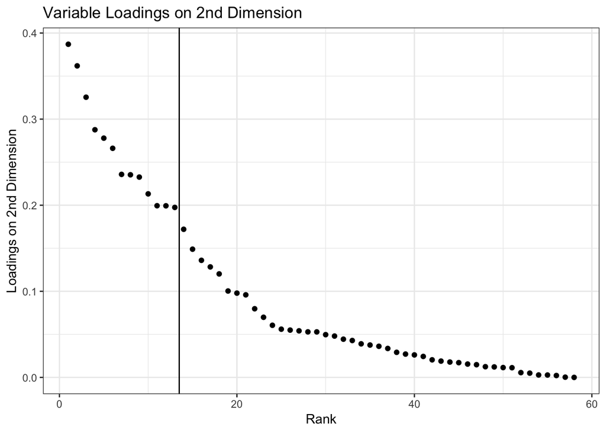

| variable | Dim.2 |
| --- | --- |
| apgar_1 | 0.2131923 |
| apgar_5 | 0.1974511 |
| ph1 | 0.3869777 |
| patch | 0.2661247 |
| ecmo | 0.2876626 |
| nitric_oxide_therapy | 0.2353476 |
| dc_28 | 0.2358185 |
| day_28_oxygen | 0.3618606 |
| discharge_oxygen | 0.2778920 |
| df_status_tube | 0.3254414 |
| hosp_2yr | 0.2326773 |
| ther2yr_any | 0.1993093 |
| tube_2yr | 0.1994139 |

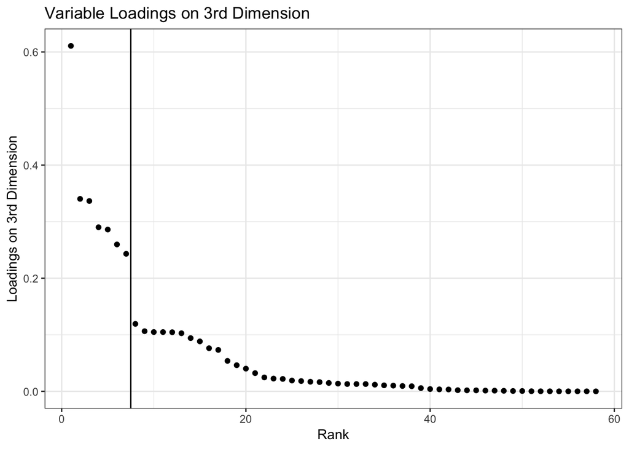

| variable | Dim.3 |
| --- | --- |
| hh | 0.3402786 |
| wt_z_birth | 0.2860579 |
| ht_z_birth | 0.2901147 |
| hc_z_birth | 0.2597135 |
| headcz_2yr | 0.6107416 |
| gender | 0.2431290 |
| gu_anomaly | 0.3365024 |

### Probabilistic graphical models

Gausian Mixture Models for K-means clustering. Three-centroid K-means using individual loadings on the three dimensions from FAMD analysis.

**Note that the K-means using factor loadings are quite different from K-means using original (imputed) dataset, the purpose of using the loadings is for interpretation**

```
## Iteration number 1
## Iteration number 2
```

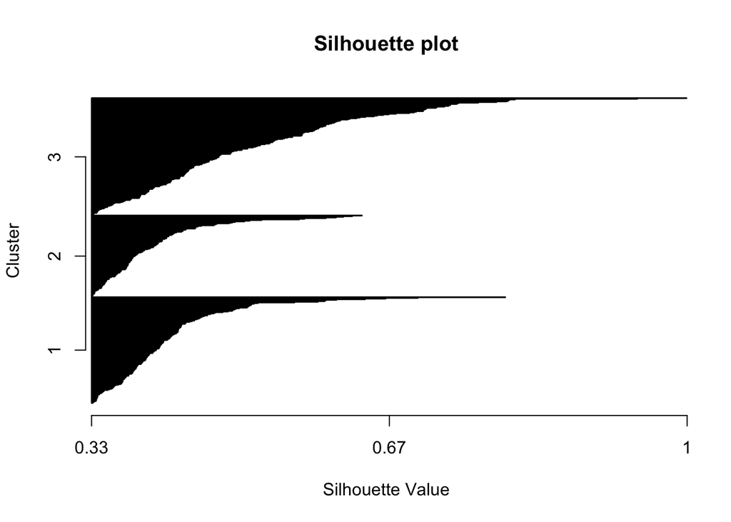

[interactive chart not shown]